# homework 3

The link to my github repository: [homework 3](https://github.com/snuuym/stats506/tree/main/homework%203)

## Problem 1

### a.

Download the file AUX_I, and determine how to read it into R. Then download the file DEMO_I. Note that each page contains a link to a documentation file for that data set. Merge the two files to create a single data.frame. Keep only records which matched. Print out the dimensions of the merged data.frame.

```r
# chatgpt taught me how to read the .xpt file
library(haven)
aux <- read_xpt("AUX_I.xpt")
demo <- read_xpt("DEMO_I.xpt")
data_merged <- merge(x = aux, y = demo, by = "SEQN") #inner join
dim(data_merged)
```

```
[1] 4582  119
```

### b.

We’ll be using the following variables. Clean up each - ensure all missing values are actually NA (rather than 999 or something), and if it’s categorical, convert it to factor with. informative levels.

Gender Citizenship status Number of children 5 years or younger in the household Annual household income - There’s also an issue with the ordering of the categories here; take a look, identify the issue, and implement a solution.

```r
library(dplyr)
#RIAGENDR
#DMDCITZN
#DMDHHSZA
#INDHHIN2 with ordering problem

df_clean <- data_merged %>%
  mutate(
    # ---- Gender ----
    RIAGENDR = case_when(
      RIAGENDR %in% c(9, 99, 999) ~ NA,
      TRUE ~ as.character(RIAGENDR)
    ),
    RIAGENDR = factor(RIAGENDR,
                 levels = c(1, 2),
                 labels = c("Male", "Female")),

    # ---- Citizenship ----
    DMDCITZN = case_when(
      DMDCITZN %in% c(7,9, 99, 999) ~ NA,
      TRUE ~ as.character(DMDCITZN)
    ),
    DMDCITZN = factor(DMDCITZN,
                      levels = c(1,2),
                      labels = c("Citizen","Non-Citizen")),

    # ---- Children under 5 ----
    DMDHHSZA = ifelse(DMDHHSZA %in% c(9, 99, 999), NA, DMDHHSZA),
    DMDHHSZA = factor(DMDHHSZA,
                      levels = c(0,1,2,3),
                      labels = c("0", "1", "2","3 and more")),


    # ---- Income ----
    INDHHIN2 = case_when(
      INDHHIN2 %in% c(77,12,13, 99, 999) ~ NA, #make the under 20k and over 20k columns NA
      TRUE ~ as.character(INDHHIN2)
    ),
    INDHHIN2 = factor(INDHHIN2,
                      levels = c(1, 2, 3, 4, 5, 6, 7, 8, 9, 10, 14, 15),
                      labels = c("$0 - $4,999", "$5,000 - $9,999", "$10,000 - $14,999",
                                 "$15,000 - $19,999","$20,000 - $24,999", "$25,000 - $34,999",
                                  "$35,000 - $44,999", "$45,000 - $54,999","$55,000 - $64,999",
                                  "$65,000 - $74,999", "$75,000 - $99,999", "$100,000 and Over")),

  )
```

### c.

The Tympanometric width measure is looks approximately like a Poisson distribution. Fit four Poisson regression models predicting a respondent’s Tympanometric width in each ear. Each model is defined below, for a specific ear and a specific set of covariates.

1R - Right ear: gender 2R - Right ear: gender, citizenship status (as categorical), number of children (as continuous), annual household income (as continuous) 1L - Left ear: gender 2L - Left ear: gender, citizenship status (as categorical), number of children (as continuous), annual household income (as continuous) Produce a table presenting the estimated incidence risk ratios for the coefficients in each model, along with the sample size for the model, the pseudo- , and AIC values. (This can be a single table, or one table for coefficients and a separate table for model statistics).

The table(s) should be “nice” - use a function such as kable from knitr, or the stargazer package (or find another approach) to generate HTML/LaTeX tables for inclusion. The results should be clearly labeled, rounded appropriately, and easily readable.

```r
library(knitr)
library(pscl)
library(dplyr)
#the idea of using midpoint to create the continuous income variable is inspired by chatgpt
income_map <- c(
  "$0 to $4,999"       = 2500,
  "$5,000 to $9,999"   = 7500,
  "$10,000 to $14,999" = 12500,
  "$15,000 to $19,999" = 17500,
  "$20,000 to $24,999" = 22500,
  "$25,000 to $34,999" = 30000,
  "$35,000 to $44,999" = 40000,
  "$45,000 to $54,999" = 50000,
  "$55,000 to $64,999" = 60000,
  "$65,000 to $74,999" = 70000,
  "$75,000 to $99,999" = 87500,
  "$100,000 and Over"  = 125000
)

df_clean$conti_income <- as.numeric(income_map[as.character(df_clean$INDHHIN2)])
#chatgpt taught me how to use ktable to present nicely

#1R
model_1 <- glm(AUXTWIDR~RIAGENDR, data = df_clean, family = "poisson",na.action = na.omit)
#2R
model_2 <- glm(AUXTWIDR~RIAGENDR+ DMDCITZN + DMDHHSZA + conti_income, data = df_clean, family = "poisson",na.action = na.omit)
#1L
model_3 <- glm(AUXTWIDL~RIAGENDR, data = df_clean, family = "poisson",na.action = na.omit)
#2L
model_4 <- glm(AUXTWIDL~RIAGENDR+ DMDCITZN + DMDHHSZA + conti_income, data = df_clean, family = "poisson",na.action = na.omit)

#this part of code is generated by chatgpt
extract_model_info <- function(model, name) {
  coefs <- coef(summary(model))

  # Incidence Rate Ratios (IRRs) and 95% CI
  irr <- exp(coef(model))
  ci <- exp(confint(model))

  # Model stats
  n <- nobs(model)
  pseudo_r2 <- pR2(model)["McFadden"]
  aic <- AIC(model)

  # Combine results
  data.frame(
    Model = name,
    Term = names(irr),
    IRR = round(irr, 3),
    CI_Lower = round(ci[, 1], 3),
    CI_Upper = round(ci[, 2], 3),
    Sample_Size = n,
    Pseudo_R2 = round(pseudo_r2, 3),
    AIC = round(aic, 1)
  )
}

# Apply to each model
results <- bind_rows(
  extract_model_info(model_1, "1R: Right Ear (Gender)"),
  extract_model_info(model_2, "2R: Right Ear (Full Model)"),
  extract_model_info(model_3, "1L: Left Ear (Gender)"),
  extract_model_info(model_4, "2L: Left Ear (Full Model)")
)
```

```
fitting null model for pseudo-r2
```

```
fitting null model for pseudo-r2
```

```
fitting null model for pseudo-r2
```

```
fitting null model for pseudo-r2
```

```r
# Create a nice table
kable(results, caption = "Incidence Rate Ratios (IRRs) for Poisson Models",
      col.names = c("Model", "Variable", "IRR", "95% CI (Lower)", "95% CI (Upper)",
                    "N", "Pseudo-R² (McFadden)", "AIC"))
```

Incidence Rate Ratios (IRRs) for Poisson Models

|  | Model | Variable | IRR | 95% CI (Lower) | 95% CI (Upper) | N | Pseudo-R² (McFadden) | AIC |
| --- | --- | --- | --- | --- | --- | --- | --- | --- |
| (Intercept)…1 | 1R: Right Ear (Gender) | (Intercept) | 84.317 | 83.910 | 84.726 | 4149 | 0.000 | 96618.5 |
| RIAGENDRFemale…2 | 1R: Right Ear (Gender) | RIAGENDRFemale | 1.009 | 1.003 | 1.016 | 4149 | 0.000 | 96618.5 |
| (Intercept)…3 | 2R: Right Ear (Full Model) | (Intercept) | 78.618 | 77.644 | 79.600 | 733 | 0.006 | 14526.9 |
| RIAGENDRFemale…4 | 2R: Right Ear (Full Model) | RIAGENDRFemale | 1.060 | 1.043 | 1.077 | 733 | 0.006 | 14526.9 |
| DMDCITZNNon-Citizen…5 | 2R: Right Ear (Full Model) | DMDCITZNNon-Citizen | 1.016 | 0.989 | 1.043 | 733 | 0.006 | 14526.9 |
| DMDHHSZA1…6 | 2R: Right Ear (Full Model) | DMDHHSZA1 | 0.971 | 0.949 | 0.994 | 733 | 0.006 | 14526.9 |
| DMDHHSZA2…7 | 2R: Right Ear (Full Model) | DMDHHSZA2 | 0.946 | 0.911 | 0.983 | 733 | 0.006 | 14526.9 |
| DMDHHSZA3 and more…8 | 2R: Right Ear (Full Model) | DMDHHSZA3 and more | 1.287 | 1.179 | 1.401 | 733 | 0.006 | 14526.9 |
| conti_income…9 | 2R: Right Ear (Full Model) | conti_income | NA | NA | NA | 733 | 0.006 | 14526.9 |
| (Intercept)…10 | 1L: Left Ear (Gender) | (Intercept) | 84.758 | 84.348 | 85.170 | 4103 | 0.000 | 98685.1 |
| RIAGENDRFemale…11 | 1L: Left Ear (Gender) | RIAGENDRFemale | 1.013 | 1.006 | 1.020 | 4103 | 0.000 | 98685.1 |
| (Intercept)…12 | 2L: Left Ear (Full Model) | (Intercept) | 78.975 | 77.998 | 79.960 | 730 | 0.009 | 15054.4 |
| RIAGENDRFemale…13 | 2L: Left Ear (Full Model) | RIAGENDRFemale | 1.083 | 1.066 | 1.101 | 730 | 0.009 | 15054.4 |
| DMDCITZNNon-Citizen…14 | 2L: Left Ear (Full Model) | DMDCITZNNon-Citizen | 1.033 | 1.006 | 1.060 | 730 | 0.009 | 15054.4 |
| DMDHHSZA1…15 | 2L: Left Ear (Full Model) | DMDHHSZA1 | 1.054 | 1.030 | 1.078 | 730 | 0.009 | 15054.4 |
| DMDHHSZA2…16 | 2L: Left Ear (Full Model) | DMDHHSZA2 | 0.939 | 0.904 | 0.975 | 730 | 0.009 | 15054.4 |
| DMDHHSZA3 and more…17 | 2L: Left Ear (Full Model) | DMDHHSZA3 and more | 0.982 | 0.889 | 1.081 | 730 | 0.009 | 15054.4 |
| conti_income…18 | 2L: Left Ear (Full Model) | conti_income | NA | NA | NA | 730 | 0.009 | 15054.4 |

### d.

From model 2L, provide evidence whether there is a difference between males and females in terms of their incidence risk ratio. Test whether the predicted value of Tympanometric width measure of the left ear differs between men and women. Include the results of the each test and their interpretation.

```r
#difference between males and females in irr
exp(coef(model_4)["RIAGENDRFemale"])
```

```
RIAGENDRFemale
      1.083238
```

```r
model_no_gender <- glm(AUXTWIDL ~ DMDCITZN + DMDHHSZA + conti_income,
                       data = df_clean, family = "poisson", na.action = na.omit)
anova(model_no_gender, model_4, test = "Chisq")
```

```
Analysis of Deviance Table

Model 1: AUXTWIDL ~ DMDCITZN + DMDHHSZA + conti_income
Model 2: AUXTWIDL ~ RIAGENDR + DMDCITZN + DMDHHSZA + conti_income
  Resid. Df Resid. Dev Df Deviance  Pr(>Chi)
1       725      10632
2       724      10535  1   96.491 < 2.2e-16 ***
---
Signif. codes:  0 '***' 0.001 '**' 0.01 '*' 0.05 '.' 0.1 ' ' 1
```

## Problem 2

```r
#sql
library(DBI)
library(RSQLite)
sakila <- dbConnect(RSQLite::SQLite(), "sakila_master.db")
```

### a.

For each store, how many customers does that store have, and what percentage of customers of that store are active in the system?

```r
#sql+R
library(dplyr)
#get the customers table
customer <- dbGetQuery(sakila, "SELECT store_id, active FROM customer")
customer <- customer %>%
  mutate(active = as.numeric(active))
active_percentage <- customer %>%
  group_by(store_id) %>%
  summarise(
    total_customers = n(),
    active_customers = sum(active),
    percent_active = 100 * mean(active)
  )
active_percentage
```

```
# A tibble: 2 × 4
  store_id total_customers active_customers percent_active
     <int>           <int>            <dbl>          <dbl>
1        1             326              318           97.5
2        2             273              266           97.4
```

```r
#sql
library(dplyr)
query <- "SELECT store_id,
                 COUNT(*) AS total_customers,
                 COUNT(active) AS total,
                 100.0 * AVG(active) AS percent_active
          FROM customer
          GROUP BY store_id; "
active_percentage <- dbGetQuery(sakila, query)
active_percentage
```

```
  store_id total_customers total percent_active
1        1             326   326       97.54601
2        2             273   273       97.43590
```

```r
#Comparison
library(microbenchmark)
microbenchmark(
  r_way = {
    customer <- dbGetQuery(sakila, "SELECT store_id, active FROM customer")
    customer <- customer %>%
      mutate(active = as.numeric(active))
    active_percentage <- customer %>%
      group_by(store_id) %>%
      summarise(
        total_customers = n(),
        active_customers = sum(active),
    percent_active = 100 * mean(active)
  )
  },
  sql_way = dbGetQuery(sakila, query),
  times = 50
)
```

```
Unit: microseconds
    expr      min       lq      mean   median       uq      max neval cld
   r_way 1135.495 1262.882 1380.7308 1335.370 1400.314 2636.505    50  a
 sql_way  148.666  159.039  177.5653  173.307  181.917  261.744    50   b
```

### b.

Generate a table identifying the names and country of each staff member.

```r
#sql+r
staff_query <- "SELECT s.first_name, s.last_name, a.address_id, a.city_id, c.country_id
          FROM staff AS s
          JOIN address AS a ON s.address_id = a.address_id
          JOIN city AS cty ON a.city_id = cty.city_id
          JOIN country AS c ON cty.country_id = c.country_id;"
staff <- dbGetQuery(sakila, staff_query)

staff_clean <- staff %>%
  mutate(full_name = paste(first_name, last_name)) %>%
  select(full_name, country_id)

staff_clean
```

```
     full_name country_id
1 Mike Hillyer         20
2 Jon Stephens          8
```

```r
#sql
#chatgpt told me how to paste the first name and last name together
staff_full_name_query <- "SELECT s.first_name || ' ' || s.last_name as full_name, c.country_id
          FROM staff AS s
          JOIN address AS a ON s.address_id = a.address_id
          JOIN city AS cty ON a.city_id = cty.city_id
          JOIN country AS c ON cty.country_id = c.country_id;"
staff_country <- dbGetQuery(sakila, staff_full_name_query)
staff_country
```

```
     full_name country_id
1 Mike Hillyer         20
2 Jon Stephens          8
```

```r
#Comparison
microbenchmark(
  r_way = {
    staff <- dbGetQuery(sakila, staff_query)
    staff_clean <- staff %>%
      mutate(full_name = paste(first_name, last_name)) %>%
      select(full_name, country_id)
  },
  sql_way = dbGetQuery(sakila, staff_full_name_query),
  times = 50
)
```

```
Unit: microseconds
    expr     min      lq     mean   median      uq      max neval cld
   r_way 568.670 577.936 613.5027 585.5825 600.691 1291.828    50  a
 sql_way  91.389  96.350 102.4516 101.2700 104.591  168.879    50   b
```

### c.

Identify the name(s) of the film(s) which was/were rented for the highest dollar value. (Assume all costs are in USD regardless of country.) (Hint: You can merge a table more than once.)

```r
#sql+r
film_query <- "SELECT f.title, p.amount
                FROM payment AS p
                JOIN rental AS r ON p.rental_id = r.rental_id
                JOIN inventory AS i ON r.inventory_id = i.inventory_id
                JOIN film AS f ON i.film_id = f.film_id;"
rented_film <- dbGetQuery(sakila, film_query)

film_clean <- rented_film %>%
                group_by(title) %>%
                  summarise(total_revenue = sum(amount)) %>%
                   filter(total_revenue == max(total_revenue))

film_clean
```

```
# A tibble: 1 × 2
  title            total_revenue
  <chr>                    <dbl>
1 TELEGRAPH VOYAGE          232.
```

```r
#sql
film_value_query <- "SELECT f.title, sum(p.amount) as total_revenue
                FROM payment AS p
                JOIN rental AS r ON p.rental_id = r.rental_id
                JOIN inventory AS i ON r.inventory_id = i.inventory_id
                JOIN film AS f ON i.film_id = f.film_id
                ORDER BY total_revenue DESC
                LIMIT 1;"
film_value <- dbGetQuery(sakila, film_value_query)

film_clean
```

[output not shown]

```
# A tibble: 1 × 2
  title            total_revenue
  <chr>                    <dbl>
1 TELEGRAPH VOYAGE          232.
```

```r
#Comparison
microbenchmark(
  r_way = {
    film <- dbGetQuery(sakila, film_query)
    film_clean <- film %>%
                group_by(title) %>%
                  summarise(total_revenue = sum(amount)) %>%
                   filter(total_revenue == max(total_revenue))
  },
  sql_way = dbGetQuery(sakila, film_value_query),
  times = 50
)
```

```
Unit: milliseconds
    expr      min       lq     mean   median       uq      max neval cld
   r_way 21.34370 21.68593 22.23438 22.12018 22.64824 25.74091    50  a
 sql_way 13.38293 13.66842 14.05477 13.93463 14.40047 14.79329    50   b
```

## Problem 3

```r
aus <- read.csv("au-500.csv")
```

### a.

What percentage of the websites are .com’s (as opposed to .net, .com.au, etc)?

```r
com_ending <- (sum(grepl("\\.com$", aus$web))/nrow(aus))*100
com_ending
```

```
[1] 0
```

### b.

What is the most common domain name amongst the email addresses? (In the email “statistics@umich.edu”, “umich.edu” is the domain name.)

```r
domain <- sub(".*@", "",aus$email)
sort(table(domain),decreasing = TRUE)[1]
```

```
hotmail.com
        114
```

### c.

What proportion of company names contain a non-alphabetic character, excluding commas and whitespace. (E.g. “Jane Doe, LLC” would not contain an eligible non-alphabetic character; “Plumber 247” would.) What about if you also exclude ampersands (“&”)?

```r
non_alpha <- "[^a-zA-Z,[:space:]]"
non_alpha_amp <- "[^a-zA-Z,&[:space:]]"

non_alpha_prop <- (sum(grepl(non_alpha, aus$company))/nrow(aus))*100
non_alpha_amp_prop <- (sum(grepl(non_alpha_amp, aus$company))/nrow(aus))*100
non_alpha_prop
```

```
[1] 9
```

```r
non_alpha_amp_prop
```

```
[1] 0.8
```

### d.

In Australia, phone have 10 digits - but unlike in the US where we write all numbers as “123-456-7890”, they write land lines and cell phones differently1:

Landlines: 12-3456-7890 Cell phones: 1234-567-890 There are two different phones listed for each record. Make all phone numbers written like cell phones. Show it works by printing the first 10 phone numbers of each colum

```r
phone1_clean <- gsub("-","",aus$phone1)
phone1_cell <- paste0(substr(phone1_clean, 1, 4), "-", substr(phone1_clean, 5, 7),"-",substr(phone1_clean, 8, 10))
phone2_clean <- gsub("-","",aus$phone2)
phone2_cell <- paste0(substr(phone2_clean, 1, 4), "-", substr(phone2_clean, 5, 7),"-",substr(phone2_clean, 8, 10))
head(phone1_cell,10)
```

```
 [1] "0381-749-123" "0799-973-366" "0855-589-019" "0260-444-682" "0214-556-085"
 [6] "0878-681-355" "0865-228-931" "0252-269-402" "0731-849-989" "0868-904-661"
```

```r
head(phone2_cell,10)
```

```
 [1] "0458-665-290" "0497-622-620" "0427-885-282" "0443-795-912" "0453-666-885"
 [6] "0451-966-921" "0427-991-688" "0415-961-606" "0411-732-965" "0461-862-457"
```

### e.

Produce a histogram of the log of the apartment numbers for all addresses. (You may assume any number at the end of the an address is an apartment number.)

[figure not shown]

```r
library(ggplot2)
#the data that truly ends with apt numbers
apt <- aus[grepl("#[0-9]*$", aus$address), ]
apt$apt_num <- as.numeric(sub(".*?(\\d+)$", "\\1", apt$address))
hist(log(apt$apt_num), main = "Histogram of log10(apartment numbers)" ,xlab ="log10(apartment number)" )
```

### f.

Benford’s law is an observation about the distribution of the leading digit of real numerical data. Examine whether the apartment numbers appear to follow Benford’s law. Do you think the apartment numbers would pass as real data?

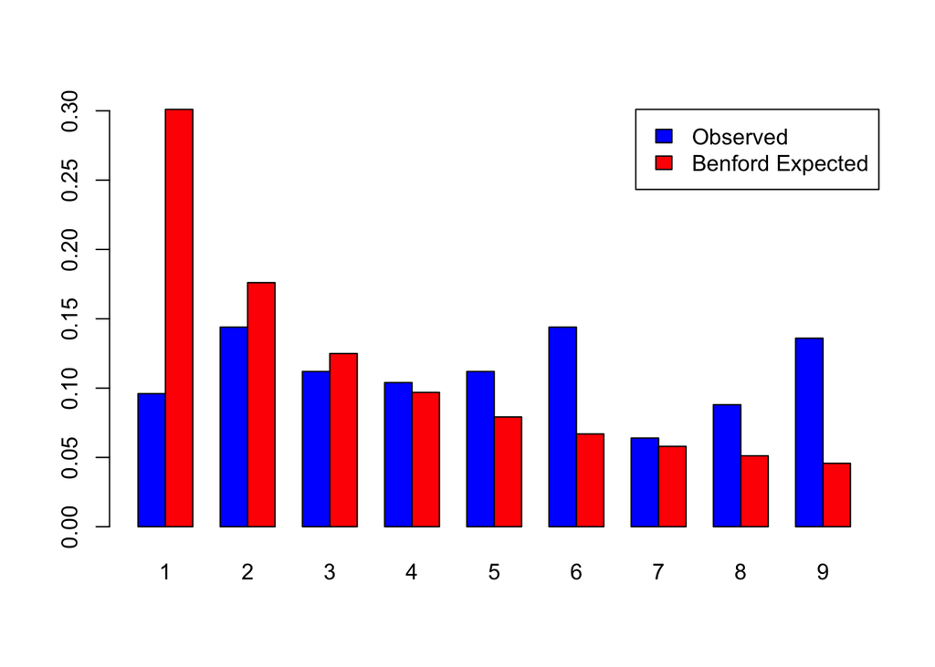

```r
#chatgpt taught me how to plot the barplots together for comparison
leading <- as.numeric(substr(as.character(apt$apt_num), 1, 1))
probs <- table(leading) / length(leading)
benford <- log10(1 + 1 / (1:9))

barplot(rbind(probs, benford),
        beside = TRUE, col = c("blue", "red"),
        names.arg = 1:9,
        legend.text = c("Observed", "Benford Expected"),
        args.legend = list(x = "topright"))
```